# Turning Points Codebook

2023-07-31

TODO: double check codebook_fun.r composite_total_avg_fun

# Overview

*Additional info to possibly include: global missing data info, links to supplemental materials, any disclaimers/info we think data users need to know to use these data accurately*

### Missing Data

- Truly missing = `NA` (blank in file or -99) = The question should have been asked of the respondent, but for a reason other than those listed below, no answer was given or recorded.

  This -99 is also given in the case of a computed subscale or total score or other summary when the percentage of missing data is outside what is allowable for missing data rules
- Not Applicable = -55 = The subject was never asked a question for some reason (conditional question)
- Don’t Know = -66 = The subject was unable to answer a question, either because he or she had no opinion or because the required information was not available (could not recall).
- Refusal/No Answer = -77 = The subject explicitly refused to answer a question or did not answer it when he or she should have.
- No Match = -88 = This situation arises when data are drawn from different sources (for example, a survey questionnaire and an administrative database), and information from one source cannot be located.
- Processing Error = -44 = For some reason, there is no answer to the question, although the subject provided one. This can result from interviewer error, incorrect coding, machine failure, or other problems

### Missing Data Rule

For summary or subscale scores that are computed with individual items, any of the above reasons are included in computing the percent of missing data

- For scales with 10 or more items, a composite score (average/total) is computed for each participant that have less than 20% of the items from that measure missing
- For scales with 7 to 9 items, a composite score (average/total) is computed for each participant that have less than 30% of the items from that measure missing
- For scales with 3 to 6 items, a composite score (average/total) is computed for each participant that have less than 33% of the items from that measure missing
- For scales with only 2 items, composite scores (average/total) are calculated on a case by case basis

# Mental Health Measures

## Brief Symptom Inventory (BSI)

### BSI Description

The BSI is a brief self-report scale used to assess psychological symptoms in adolescents and adults.

For the present study, 19 items from the BSI were collected in order to calculate the Somatization, Anxiety, and Depression subscales.

Item numbers in this data set may not match original item numbers from the BSI exactly is this correct - what other info do we need to include about mismatch between ours and original measure?

No items need to be reverse scored. Higher scores indicate more severe mental health symptoms.

Reference: [@derogatis1983brief](https://www.cambridge.org/core/journals/psychological-medicine/article/abs/brief-symptom-inventory-an-introductory-report/307F805810B165ED58581E355F24329F); [DOI](https://doi.org/10.1017/S0033291700048017)

### BSI Variables

#### Value Labels

All BSI variables have the same response options.

| 1 | 2 | 3 | 4 | 5 |
| --- | --- | --- | --- | --- |
| Not at all | A little bit | Moderately | Quite a bit | Very much |

#### Survey Items

BSI survey items are presented in the following table:

During the past week, how much were you bothered by…

| Variable | Description | Notes |
| --- | --- | --- |
| bsi1 | nervousness or shakiness inside? |  |
| bsi2 | faintness or dizziness? |  |
| bsi3 | pains in your heart or chest? |  |
| bsi4 | thoughts of ending your life? | This item was not asked for TC who were incarcerated while assessment were conducted |
| bsi5 | feeling suddenly scared for no reason? |  |
| bsi6 | feeling lonely? |  |
| bsi7 | feeling blue? |  |
| bsi8 | feeling no interest in things? |  |
| bsi9 | feeling fearful? |  |
| bsi10 | nausea or upset stomach? |  |
| bsi11 | trouble getting (catching) your breath? |  |
| bsi12 | hot or cold spells? |  |
| bsi13 | numbness or tingling in parts of your body? |  |
| bsi14 | feeling hopeless about the future? |  |
| bsi15 | feeling weak in parts of your body? |  |
| bsi16 | feeling tense or keyed up? |  |
| bsi17 | spells of terror or panic? |  |
| bsi18 | feeling so restless you couldn’t sit still? |  |
| bsi19 | feelings of worthlessness? |  |

#### Scale and Subscales

Information on the total score and subscale variables are below. Variables were constructed by summing included items.

[output not shown]

*Range of possible values

### Summary Statistics

#### Descriptive Statistics

Descriptive statistics are presented below for each item, total, and subscale score:

| Variable | Mean | SD | Range* | % Missing |
| --- | --- | --- | --- | --- |
| bsi1 | 2.43 | 1.34 | 1-5 | 0% |
| bsi2 | 1.36 | 0.78 | 1-5 | 0% |
| bsi3 | 1.42 | 0.9 | 1-5 | 0% |
| bsi4 | 1.21 | 0.71 | 1-5 | 2.33% |
| bsi5 | 1.44 | 0.76 | 1-4 | 0% |
| bsi6 | 2.18 | 1.31 | 1-5 | 0% |
| bsi7 | 2.12 | 1.22 | 1-5 | 0% |
| bsi8 | 2.03 | 1.19 | 1-5 | 0% |
| bsi9 | 1.65 | 0.97 | 1-5 | 0% |
| bsi10 | 1.95 | 1.28 | 1-5 | 0% |
| bsi11 | 1.68 | 0.99 | 1-5 | 0% |
| bsi12 | 1.66 | 1.11 | 1-5 | 0% |
| bsi13 | 1.75 | 1.12 | 1-5 | 0% |
| bsi14 | 1.73 | 1.08 | 1-5 | 0% |
| bsi15 | 1.74 | 1.03 | 1-5 | 0% |
| bsi16 | 2.29 | 1.28 | 1-5 | 0% |
| bsi17 | 1.52 | 0.87 | 1-5 | 0% |
| bsi18 | 1.99 | 1.28 | 1-5 | 0% |
| bsi19 | 1.68 | 1.08 | 1-5 | 0% |
| bsi_total | 33.82 | 12.27 | 19-79 | 0% |
| bsi_soma | 11.57 | 4.68 | 7-25 | 0% |
| bsi_anx | 11.33 | 4.86 | 6-28 | 0% |
| bsi_dep | 10.93 | 5.05 | 6-27 | 0% |

*Range of data values

#### Distributions

Distributions are presented below for the total score and each subscale:

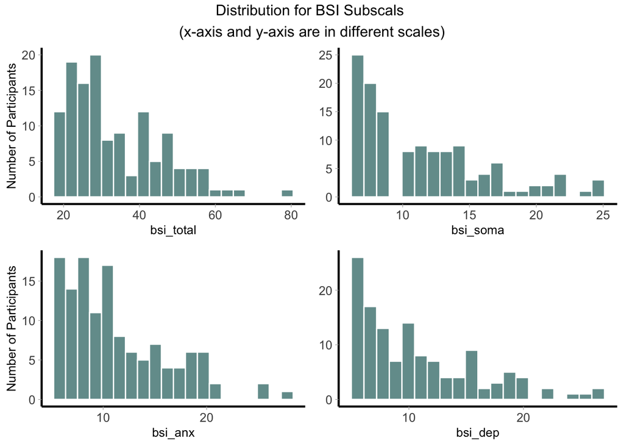

#### Clinical cutoff

TODO: Maria/Shaina, please confirm weather we need this section or not.

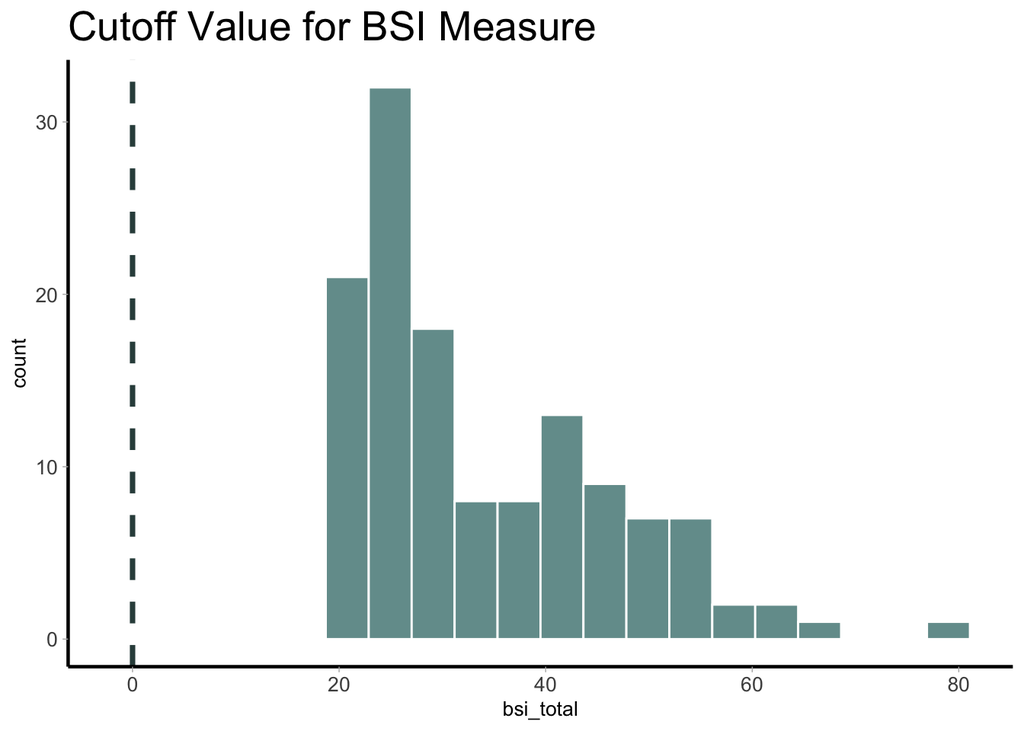

## Center for Epidemiologic Studies Depression Scale (CES-D)

### CES-D Description

The CES-D is self-report scale used to assess major dimensions of depression.

All 20 items from the CES-D were collected and two subscales were calculated: positive affect and depressive symptoms. Four items (`c4`, `c8`, `c12`, and `c16`) should be reverse scored which is noted in the variable table below and the reverse scored variables are provided (`c4_r`, `c8_r`, `c12_r`, and `c16_r`). Higher scores indicate the presence of more symptoms.

Four additional variables (`c21`-`c24`) were included in this section to assess suicidality. Variables `c22` and `c23` are only applicable if participants responded “Yes” to `c21`.

The missing data rule was not applied since all participants had less than 20% missing data. Missing data for each variable is presented in the descriptive statistics table below.

Reference: [@radloff1977ces](https://journals.sagepub.com/doi/abs/10.1177/014662167700100306); [DOI](https://doi.org/10.1177%2F014662167700100306)

- Additional References:
  - Cutoff Information: [@henry2018determining](https://www.sciencedirect.com/science/article/pii/S0165032717319274?casa_token=Aan1lg2Z8mUAAAAA:aun9j7DwQRQLhRqhbBJQfpPQG4fDv4yjN1WGHvzv-Hh9Pu58f7IhyGyPTDJmeAUZWonwmO7tfi4); [DOI](https://doi.org/10.1016/j.jad.2018.02.071)
  - Items for Potential Subscales: [@canady2009measurement](https://connect.springerpub.com/content/sgrjnm/17/2/91.abstract); DOI

### CES-D Variables

#### Value Labels

All CES-D survey items (`c1`-`c20`) have the same response options.

| 1 | 2 | 3 | 4 |
| --- | --- | --- | --- |
| Rarely or none of the time | Some or a little of the time | Occasionally or a moderate amount of time | Most or all of the time |

Additional variables on suicidality (`c21`-`c24`) share the same response options.

| 0 | 1 |
| --- | --- |
| No | Yes |

#### Survey Items

All CES-D survey items are presented in the following table:

| Variable | Description | Notes |
| --- | --- | --- |
| c1 | During the past week, I was bothered by things that usually don’t bother me |  |
| c2 | I did not feel like eating; my appetite was poor |  |
| c3 | I felt that I could not shake off the blues even with help from my family or friends |  |
| c4 | During the past week, I felt that I was just as good as other people | This item should be reverse scored. `c4_r` is reverse scored |
| c5 | I had trouble keeping my mind on what I was doing. |  |
| c6 | I felt depressed |  |
| c7 | During the past week, I felt that everything I did was an effort |  |
| c8 | I felt hopeful about the future | This item should be reverse scored. `c8_r` is reverse scored |
| c9 | I thought my life had been a failure |  |
| c10 | During the past week, I felt fearful |  |
| c11 | My sleep was restless |  |
| c12 | I was happy | This item should be reverse scored. `c12_r` is reverse scored |
| c13 | During the past week, I talked less than usual |  |
| c14 | I felt lonely |  |
| c15 | People were unfriendly |  |
| c16 | During the past week, I enjoyed life | This item should be reverse scored. `c16_r` is reverse scored |
| c17 | I had crying spells |  |
| c18 | I felt sad |  |
| c19 | During the past week, I felt that people disliked me |  |
| c20 | I could not “get going” |  |
| c21 | In the past 6 months, have you ever thought about killing yourself? | This item was not asked for TC who were incarcerated while assessment were conducted |
| c22 | In the past 6 months, have you thought often about killing yourself? | Skipped if answered No for `c21`. This item was not asked for TC who were incarcerated while assessment were conducted |
| c23 | In the past 6 months, did you have a plan for killing yourself? | Skipped if answered No for `c21`. This item was not asked for TC who were incarcerated while assessment were conducted |
| c24 | In the past 6 months, have you tried to kill yourself? | This item was not asked for TC who were incarcerated while assessment were conducted |

#### Scale and Subscales

Information on the aggregated scale and subscale variables are below. Total and subscale variables were constructed by summing corresponding items.

[output not shown]

*Range of possible values; `_r` Reverse scored variable

### Summary Statistics

#### Descriptive Statistics

Descriptive statistics are presented below for each item, total, and subscale score:

| Variable | Mean | SD | Range* | % Missing |
| --- | --- | --- | --- | --- |
| c1 | 1.70 | 0.93 | 1-4 | 0% |
| c2 | 2.05 | 1.07 | 1-4 | 0% |
| c3 | 1.80 | 1.06 | 1-4 | 0% |
| c4 | 3.19 | 1.03 | 1-4 | 0% |
| c5 | 2.52 | 1.09 | 1-4 | 0% |
| c6 | 2.09 | 1.17 | 1-4 | 0% |
| c7 | 2.60 | 1.18 | 1-4 | 0% |
| c8 | 3.19 | 0.98 | 1-4 | 0% |
| c9 | 1.66 | 1.03 | 1-4 | 0% |
| c10 | 1.47 | 0.76 | 1-4 | 0% |
| c11 | 2.53 | 1.09 | 1-4 | 0% |
| c12 | 3.12 | 0.93 | 1-4 | 0% |
| c13 | 1.77 | 1.01 | 1-4 | 0.78% |
| c14 | 2.13 | 1.15 | 1-4 | 0% |
| c15 | 1.57 | 0.89 | 1-4 | 0% |
| c16 | 3.12 | 0.97 | 1-4 | 0.78% |
| c17 | 1.67 | 0.95 | 1-4 | 0% |
| c18 | 2.11 | 1.11 | 1-4 | 0% |
| c19 | 1.58 | 0.88 | 1-4 | 0% |
| c20 | 2.02 | 0.99 | 1-4 | 0% |
| c21 | 0.19 | 0.39 | 0-1 | 3.88% |
| c22 | 0.57 | 0.51 | 0-1 | 82.17% |
| c23 | 0.23 | 0.43 | 0-1 | 82.95% |
| c24 | 0.03 | 0.18 | 0-1 | 2.33% |
| cesd_total | 38.64 | 13.69 | 20-70 | 0% |
| cesd_dep_symp | 28.66 | 10.33 | 15-52 | 0% |
| cesd_pos_aff | 7.37 | 3.29 | 4-15 | 0% |

*Range of data values

#### Distributions

Distributions are presented below for the total score and each subscale:

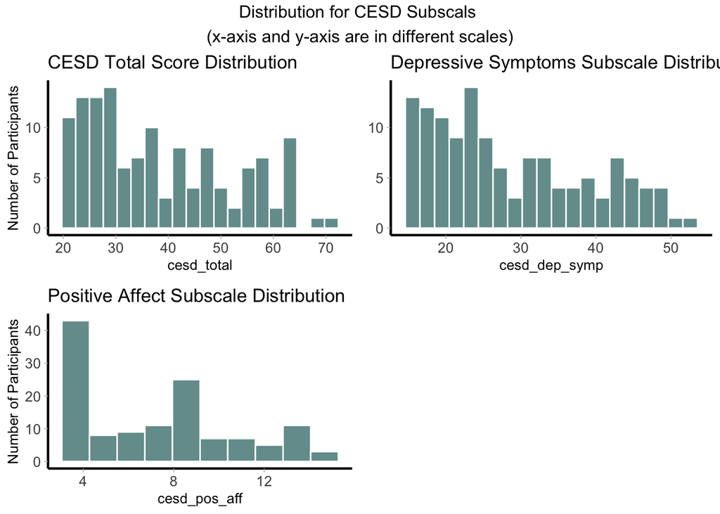

#### Clinical Categories

The distribution for CES-D scores alongside clinical cutoffs are presented below.

Reference: [@henry2018determining](https://www.sciencedirect.com/science/article/pii/S0165032717319274?casa_token=Aan1lg2Z8mUAAAAA:aun9j7DwQRQLhRqhbBJQfpPQG4fDv4yjN1WGHvzv-Hh9Pu58f7IhyGyPTDJmeAUZWonwmO7tfi4); [DOI](https://doi.org/10.1016/j.jad.2018.02.071)

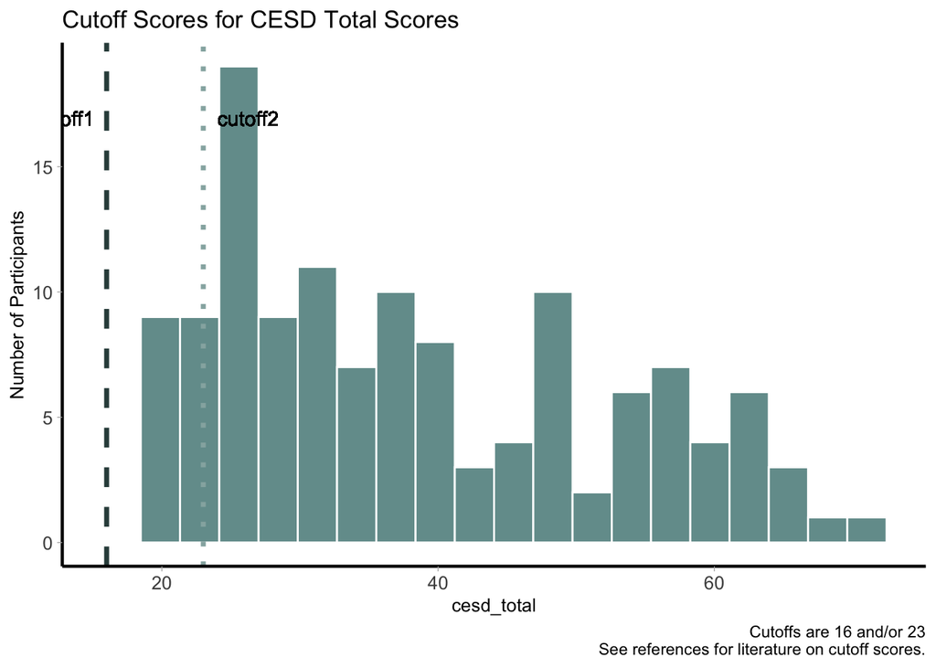

## Coronavirus Impacts Questionnaire (CIQ)

### CIQ Description

The CIQ is self-report survey used to assess the financial, resource, and psychological impacts of COVID-19.

For the present study, 3 items from the CIQ were collected in order to construct the psychological impacts scale.

The missing data rule was not applied since there is no missing data among CIQ variables.

Reference: [@conway2020social](https://psyarxiv.com/z2x9a/)

### CIQ Variables

#### Value Labels

All CIQ variables have the same response options.

| 1 | 2 | 3 | 4 | 5 | 6 | 7 |
| --- | --- | --- | --- | --- | --- | --- |
| Not true of me at all | 2 | 3 | 4 | 5 | 6 | Very true of me |

#### Survey Items

All CIQ survey items are presented in the following table:

| Variable | Description | Notes |
| --- | --- | --- |
| ciq1 | I have become depressed because of the Coronavirus (COVID-19). |  |
| ciq2 | The Coronavirus (COVID-19) outbreak has impacted my psychological health negatively. |  |
| ciq3 | The Coronavirus (COVID-19) pandemic has NOT made me feel any worse than I did. | This item should be reverse scored. `ciq3_r` is reverse scored |

#### Scale and Subscales

Information on the total score and subscale variables are below. Variables were constructed by summing included items.

| Variable Name | Scale (# of items) | Scale Construction | Range* | Alpha |
| --- | --- | --- | --- | --- |
| ciq_psych_total | Total Score (3) | `ciq1`, `ciq2`, `ciq3_r` | 3-21 | 0.778 |

*Range of possible values; `_r` Reverse scored variable

### Summary Statistics

#### Descriptive Statistics

Descriptive statistics are presented below for each item and the total score:

| Variable | Mean | SD | Range* | % Missing |
| --- | --- | --- | --- | --- |
| ciq1 | 2.49 | 1.95 | 1-7 | 0% |
| ciq2 | 2.89 | 2.02 | 1-7 | 0% |
| ciq3 | 3.62 | 2.53 | 1-7 | 0% |
| ciq_psych_total | 9.76 | 5.45 | 3-21 | 0% |

*Range of data values

#### Distributions

The distribution for the total score is presented below:

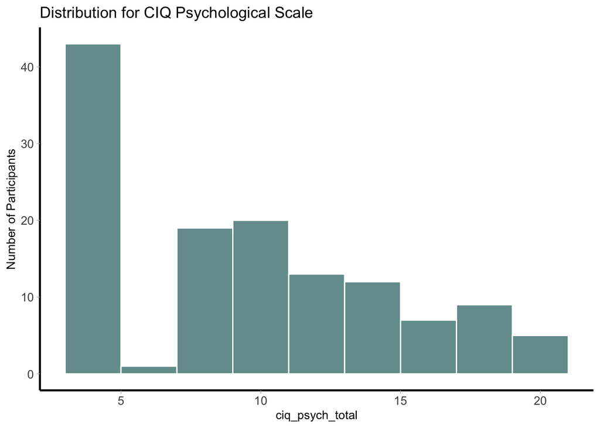

## The Drug Abuse Screening Test (DAST)

### DAST Description

TODO: ROW DATA INCORRECTLY CLEANED, WILL NEED RE_CLEAN!

TODO: CHECK AFTER DATA IS CLEANED

The DAST is a self-report instrument used to assess problems related to substance use.

For the present study, 22 items from the DAST were collected and a total score was constructed. No subscales were created for this measure as there was a lack of evidence supporting a subscale structure.

Two items (`d4` and `d5`) should to be reverse scored which is noted in the variable table below and the reverse scored variables are provided (`d4_r` and `d5_r`). Higher scores indicate more problems related to substance use.

<TODO: Maria please check if you like this sentences here> TC who are incarcerated while assessment was done weren’t asked for this survey.

TODO: CONFIRM THIS IS CORRECT AND IF SHOULD BE APPLIED IN TABLES BELOW - specify -77 The missing data rule was applied. Calculations were completed only with participants that had less than 20% missing data (this includes `-77` responses)

Reference: [@gavin1989diagnostic](https://onlinelibrary.wiley.com/doi/abs/10.1111/j.1360-0443.1989.tb03463.x);[DOI](https://doi.org/10.1111/j.1360-0443.1989.tb03463.x)

### DAST Variables

#### Value Labels

All The Drug Abuse Screening Test variables have the same response options.

| 1 | 0 |
| --- | --- |
| Yes | No |

TODO: CONFIRM THIS TABLE SHOULD BE INCLUDED AND WHAT VARIABLES THEY APPLY TO Re-coded total value label `dast_total_r`

| 0 | 1 | 2 | 3 | 4 |
| --- | --- | --- | --- | --- |
| None | Low | Intermediate (likely meets DSM criteria) | Substantial | Severe |

#### Survey Items

All DAST survey items are presented in the following table:

This questionnaire deals with certain drug use and social behavior patterns. Please answer each of the items truthfully by stating Yes or No to me, thinking about the past 6 months.

| Variable | Description | Notes |
| --- | --- | --- |
| dast_screen | Is TC currently pregnant? |  |
| d1a | Have you used drugs other than those required for medical reasons in the last 6 months? |  |
| d2a | 2A. Have you misused prescription drugs in the last 6 months? |  |
| d2b | 2B. Have you misused prescription drugs in the last 6 months? |  |
| d3 | Have you misused more than one drug at a time in the last 6 months? |  |
| d4 | Could you get through the week without using drugs in the last 6 months? | This item should be reverse scored. `d4_r` is reverse scored |
| d5 | Were you always able to stop using drugs when you wanted to in the last 6 months? | This item should be reverse scored. `d4_r` is reverse scored |
| d6 | Have you ever had “blackouts” or “flashbacks” as a result of drug use in the last 6 months? |  |
| d7 | Have you ever felt bad or guilty about your drug use in the last 6 months? |  |
| d8 | Has your partner/spouse ever complained about your involvement with drugs in the last 6 months? |  |
| d9 | Has (your) drug misuse created problems between you and your partner/spouse in the last 6 months? |  |
| d10 | Have you lost friends because of your use of drugs in the last 6 months? |  |
| d11 | Have you neglected your family because of your use of drugs in the last 6 months? |  |
| d12 | Have you been in trouble at work because of your use of drugs in the last 6 months? |  |
| d13 | Have you lost a job because of drug misuse in the last 6 months? |  |
| d14 | Have you gotten into fights when under the influence of drugs in the last 6 months? |  |
| d15 | Have you engaged in illegal activities in order to obtain drugs in the last 6 months? |  |
| d16 | Have you been arrested for possession of illegal drugs in the last 6 months? |  |
| d17 | Have you experienced withdrawal symptoms (felt sick) when you stopped taking drugs in the last 6 months? |  |
| d18 | Have you had medical problems as a result of your drug use… (e.g., memory loss, hepatitis, convulsions, bleeding, etc.) in the last 6 months? |  |
| d19 | Have you gone to anyone for help for a drug problem in the last 6 months? |  |
| d20 | Have you been involved in a treatment program especially related to drug use in the last 6 months? |  |

#### Scale and Subscales

Information on the total score is below. The total score was constructed by summing all items.

DATA CLEANING TODO: need check the total

[output not shown]

*Range of possible values; `_r` Reverse scored variable

### Summary Statistics

#### Descriptive Statistics

Descriptive statistics are presented below for each item and the total score.

For binary items:

| Variable | No N | No % | Yes N | Yes % | % Missing |  |
| --- | --- | --- | --- | --- | --- | --- |
| d1a | 1 | 0.8% | 52 | 40.3% |  | 58.91% |
| d2a | 47 | 36.4% | 5 | 3.9% | 59.69% |  |
| d2b | 0 | 0% | 1 | 0.8% | 99.22% |  |
| d3 | 38 | 29.5% | 15 | 11.6% | 58.91% |  |
| d4 | 16 | 12.4% | 37 | 28.7% | 58.91% |  |
| d5 | 16 | 12.4% | 37 | 28.7% | 58.91% |  |
| d6 | 42 | 32.6% | 11 | 8.5% | 58.91% |  |
| d7 | 25 | 19.4% | 28 | 21.7% | 58.91% |  |
| d8 | 37 | 28.7% | 16 | 12.4% | 58.91% |  |
| d9 | 34 | 26.4% | 19 | 14.7% | 58.91% |  |
| d10 | 43 | 33.3% | 10 | 7.8% | 58.91% |  |
| d11 | 37 | 28.7% | 16 | 12.4% | 58.91% |  |
| d12 | 47 | 36.4% | 6 | 4.7% | 58.91% |  |
| d13 | 47 | 36.4% | 6 | 4.7% | 58.91% |  |
| d14 | 44 | 34.1% | 9 | 7% | 58.91% |  |
| d15 | 42 | 32.6% | 11 | 8.5% | 58.91% |  |
| d16 | 50 | 38.8% | 3 | 2.3% | 58.91% |  |
| d17 | 34 | 26.4% | 19 | 14.7% | 58.91% |  |
| d18 | 43 | 33.3% | 9 | 7% | 59.69% |  |
| d19 | 40 | 31% | 13 | 10.1% | 58.91% |  |
| d20 | 41 | 31.8% | 12 | 9.3% | 58.91% |  |

For the total score:

| Variable | Mean | SD | Range | % Missing |
| --- | --- | --- | --- | --- |
| dast_total | 5.53 | 4.6 | 1-17 | 58.91% |

*Range of data values

#### Distributions

The distribution for the total score is presented below:

<#TODO: Maria, should I use reversed total score for this distributions?>

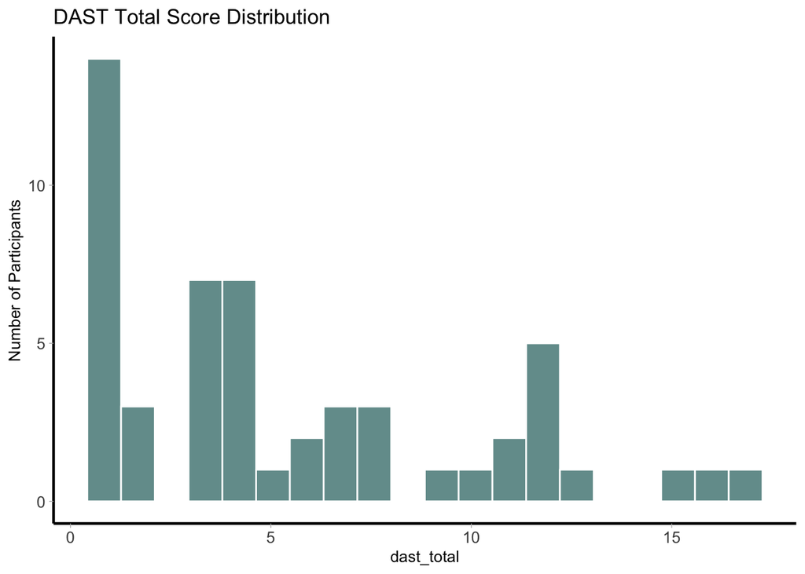

#### Clinical Categories

The distribution for the total score alongside clinical severity categories are presented below.

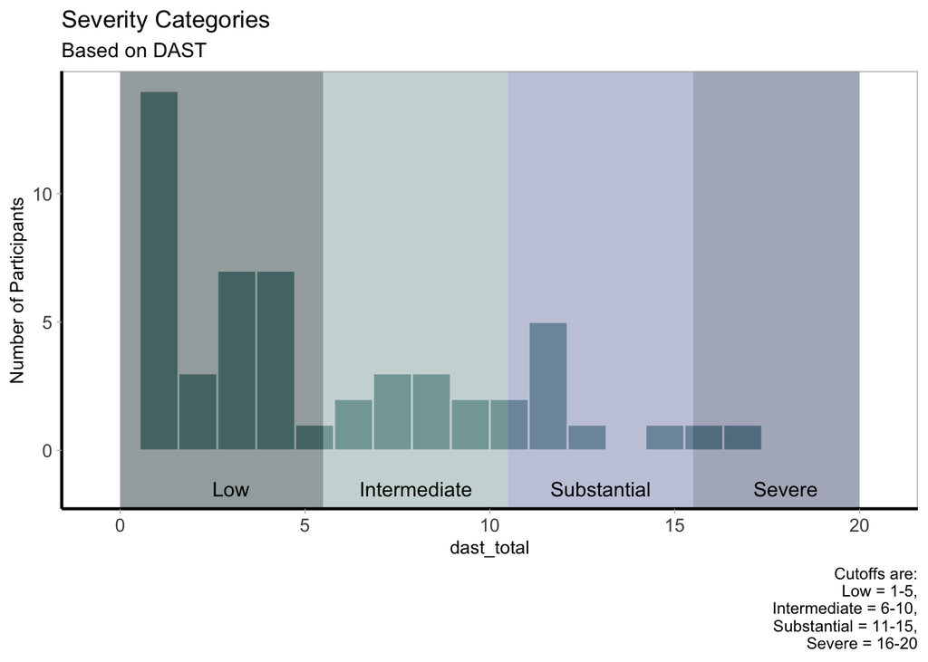

## Conflict Tactics Scales (CTS)

### CTS Description

The CTS is a self-report measure used to assess tactics used when there is conflict in a relationship.

For the present study, all 20 items from the CTS short form were collected, and all scales (Negotiation, Physical Assault, and Psychological Aggression) and supplemental scales (Assault and Sexual Coercion) were calculated.

Authors describe that internal reliability is not appropriate for the CTS measure. CTS should not have a calculated total/average composite score. Instead, CTS has three different ways of scoring (Prevalence, Severity, Mutuality).

No items need to be reverse scored. TODO: How to word directionality with current values/labels. (e.g., Higher scores indicate …”

TODO: CONFIRM & CHECK CALC CODE The missing data rule was applied. Calculations were completed only with participants that had less than 20% missing data (this includes `-77` responses)

Reference: [@straus2004short](https://connect.springerpub.com/content/sgrvv/19/5/507.abstract); DOI

### CTS Variables

#### Value Labels

All CTS variables have the same response options.

| 1 | 2 | 3 | 4 | 5 | 6 | 7 | 8 |
| --- | --- | --- | --- | --- | --- | --- | --- |
| This has never happened | Once in the past year | Twice in the past year | 3-5 times in the past year | 6-10 times in the past year | 11-20 times in the past year | More than 20 times in the past year | Not in the past year, but it did happen before |

#### Survey Items

All CTS survey items are presented in the following table: Incarcerated TC weren’t administered for this survey

Incarcerated TC weren’t administered for this survey

Please indicate how many times you did each of these things in the past year, and how many times you partner did them in the past year.

| Variable | Description | Notes |
| --- | --- | --- |
| cts screen | Have you been in a (romantic) relationship in the past year? | If TC answered No for this question the rest of survey will be skipped |
| ct1 | I explained my side or suggested a compromise for a disagreement with my partner. |  |
| ct2 | My partner explained their side or suggested a compromise for a disagreement with me. |  |
| ct3 | I insulted or swore or shouted or yelled at my partner. |  |
| ct4 | My partner insulted or swore or shouted or yelled at me. |  |
| ct5 | I had a sprain, bruise, or small cut, or felt (physical) pain the next day because of a fight with my partner. |  |
| ct6 | My partner had a sprain, bruise, or small cut or felt (physical) pain the next day because of a fight with me. |  |
| ct7 | I showed respect for, or showed that I cared about my partner’s feelings about an issue we disagreed on. |  |
| ct8 | My partner showed respect for, or showed that they cared about my feelings about an issue we disagreed on. |  |
| ct9 | I pushed, shoved, or slapped my partner. |  |
| ct10 | My partner pushed, shoved, or slapped me. |  |
| ct11 | I punched or kicked or beat-up my partner. |  |
| ct12 | My partner punched or kicked or beat-me-up. |  |
| ct13 | I destroyed something belonging to my partner or threatened to hit my partner. |  |
| ct14 | My partner destroyed something belonging to me or threatened to hit me. |  |
| ct15 | I went see a doctor (M.D.) or needed to see a doctor because of a fight with my partner. |  |
| ct16 | My partner went to see a doctor (M.D.) or needed to see a doctor because of a fight with me. |  |
| ct17 | I used force (like hitting, holding down, or using a weapon) to make my partner have sex. |  |
| ct18 | My partner used force (like hitting, holding down, or using a weapon) to make me have sex. |  |
| ct19 | I insisted on sex when my partner did not want to or insisted on sex without a condom (but did not use physical force). |  |
| ct20 | My partner insisted on sex when I did not want to or insisted on sex without a condom (but did not use physical force). |  |
| cts parent screen | Have you parented a child (under 18) in the past year? |  |

#### Scale and Subscales

TODO: NEED fill Range once we understand how composite scores were created

| Variable Name | Scale (# of items) | Score Method | Scale Construction | Range* |
| --- | --- | --- | --- | --- |
| cts_psy_agg_ind_sev | TC Psychological Aggression (2) | Severity | `ct3`, `ct13` |  |
| cts_injury_ind_sev | TC Physical Injury (2) | Severity | `ct5`, `ct15` |  |
| cts_assault_ind_sev | TC Assault (2) | Severity | `ct9`, `ct11` |  |
| cts_sex_ind_sev | TC Sexual Cohesion (2) | Severity | `ct17`, `ct19` |  |
| cts_psy_agg_part_sev | Partner Psychological Aggression (2) | Severity | `ct4`, `ct14` |  |
| cts_injury_part_sev | Partner Physical Injury (2) | Severity | `ct6`, `ct16` |  |
| cts_assault_part_sev | Partner Assault (2) | Severity | `ct10`, `ct12` |  |
| cts_sex_part_sev | Partner Sexual Cohesion (2) | Severity | `ct18`, `ct20` |  |
| cts_psy_agg_ind_prev | TC Psychological Aggression (2) | Prevalence | `ct3`, `ct13` |  |
| cts_injury_ind_prev | TC Physical Injury (2) | Prevalence | `ct5`, `ct15` |  |
| cts_assault_ind_prev | TC Assault (2) | Prevalence | `ct9`, `ct11` |  |
| cts_sex_ind_prev | TC Sexual Cohesion (2) | Prevalence | `ct17`, `ct19` |  |
| cts_psy_agg_part_prev | Partner Psychological Aggression (2) | Prevalence | `ct4`, `ct14` |  |
| cts_injury_part_prev | Partner Physical Injury (2) | Prevalence | `ct6`, `ct16` |  |
| cts_assault_part_prev | Partner Assault (2) | Prevalence | `ct10`, `ct12` |  |
| cts_sex_part_prev | Partner Sexual Cohesion (2) | Prevalence | `ct18`, `ct20` |  |
| cts_psy_agg_mutual | Psychological Aggression (4) | Mutuality | `ct3`, `ct13`, `ct4`, `ct14` |  |
| cts_injury_mutual | Physical Injury (4) | Mutuality | `ct5`, `ct15`, `ct6`, `ct16` |  |
| cts_assault_mutual | Assaul (4)t | Mutuality | `ct9`, `ct11`, `ct10`, `ct12` |  |
| cts_sex_mutual | Sexual Cohesion (4) | Mutuality | `ct17`, `ct19`, `ct18`, `ct20` |  |
| cts_negotiate_ind | TC Negotiation (2) |  | `ct1`, `ct7` |  |
| cts_negotiate_part | Partner Negotiation (2) |  | `ct2`, `ct8` |  |

*Range of possible values

### Summary Statistics

#### Descriptive Statistics

Descriptive statistics are presented below for each item and subscale score:

| Variable | Mean | SD | Range* | % Missing |
| --- | --- | --- | --- | --- |
| ct1 | 4.55 | 1.63 | 1-8 | 18.6% |
| ct2 | 4.32 | 1.67 | 1-8 | 18.6% |
| ct3 | 5.06 | 2.22 | 1-8 | 17.83% |
| ct4 | 5.12 | 2.21 | 1-8 | 17.83% |
| ct5 | 7.17 | 1.9 | 1-8 | 17.83% |
| ct6 | 7.34 | 1.91 | 1-8 | 17.83% |
| ct7 | 5.08 | 1.49 | 1-8 | 17.83% |
| ct8 | 4.91 | 1.69 | 1-8 | 17.83% |
| ct9 | 6.99 | 2.29 | 1-8 | 17.83% |
| ct10 | 7.11 | 1.96 | 1-8 | 18.6% |
| ct11 | 7.47 | 1.77 | 1-8 | 17.83% |
| ct12 | 7.40 | 1.64 | 1-8 | 17.83% |
| ct13 | 7.21 | 2.01 | 1-8 | 17.83% |
| ct14 | 7.08 | 2 | 1-8 | 17.83% |
| ct15 | 7.66 | 1.38 | 1-8 | 17.83% |
| ct16 | 7.87 | 0.96 | 1-8 | 17.83% |
| ct17 | 8.00 | 0 | 8-8 | 17.83% |
| ct18 | 7.95 | 0.49 | 3-8 | 17.83% |
| ct19 | 7.83 | 0.93 | 1-8 | 17.83% |
| ct20 | 7.52 | 1.47 | 1-8 | 17.83% |
| cts_screen | 1.00 | 0 | 1-1 | 17.83% |
| cts_psy_agg_ind_sev | 0.90 | 0.63 | 0-2 | 17.83% |
| cts_psy_agg_part_sev | 0.92 | 0.69 | 0-2 | 17.83% |
| cts_injury_ind_sev | 0.23 | 0.54 | 0-2 | 17.83% |
| cts_injury_part_sev | 0.13 | 0.39 | 0-2 | 17.83% |
| cts_assault_ind_sev | 0.25 | 0.59 | 0-2 | 17.83% |
| cts_assault_part_sev | 0.32 | 0.7 | 0-2 | 17.83% |
| cts_sex_ind_sev | 0.04 | 0.19 | 0-1 | 17.83% |
| cts_sex_part_sev | 0.11 | 0.35 | 0-2 | 17.83% |
| cts_negotiate_ind | 25.88 | 12.42 | 1-40 | 17.83% |
| cts_negotiate_part | 22.93 | 13.06 | 0-40 | 17.83% |
| cts_psy_agg_ind_prev | 0.75 | 0.44 | 0-1 | 17.83% |
| cts_psy_agg_part_prev | 0.73 | 0.45 | 0-1 | 17.83% |
| cts_injury_ind_prev | 0.17 | 0.38 | 0-1 | 17.83% |
| cts_injury_part_prev | 0.11 | 0.32 | 0-1 | 17.83% |
| cts_assault_ind_prev | 0.18 | 0.39 | 0-1 | 17.83% |
| cts_assault_part_prev | 0.19 | 0.39 | 0-1 | 17.83% |
| cts_sex_ind_prev | 0.04 | 0.19 | 0-1 | 17.83% |
| cts_sex_part_prev | 0.10 | 0.31 | 0-1 | 17.83% |
| cts_psy_agg_mutual | 2.22 | 1.28 | 0-3 | 17.83% |
| cts_injury_mutual | 0.45 | 1.02 | 0-3 | 17.83% |
| cts_assault_mutual | 0.55 | 1.09 | 0-3 | 17.83% |
| cts_sex_mutual | 0.18 | 0.58 | 0-3 | 17.83% |

*Range of data values

#### Distributions

Distributions are presented below for each subscale I’d like your input on how to abbriviate the x axix and title.

##### Severity distributions

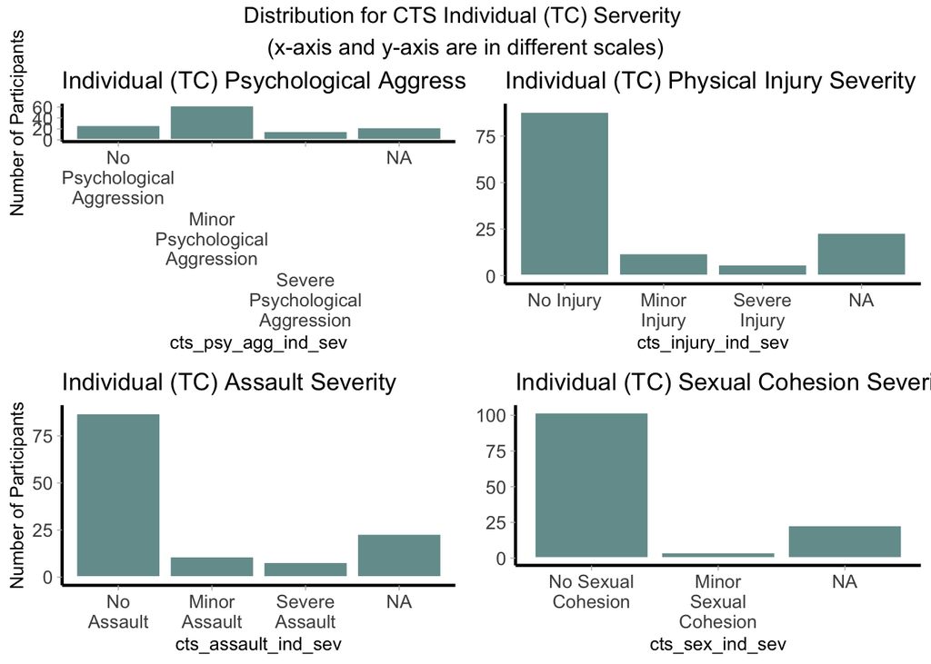

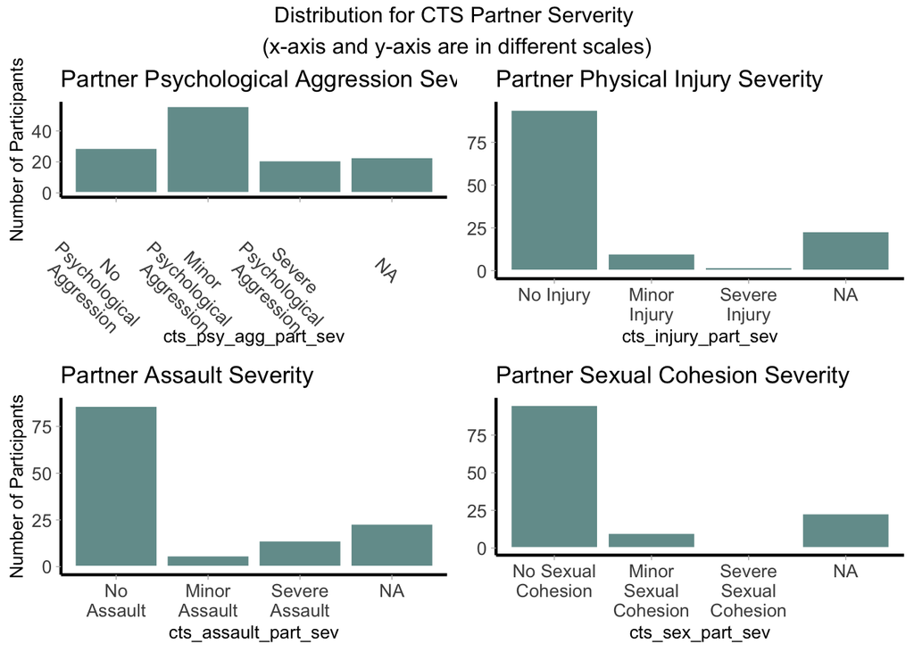

##### Prevalence distributions

TODO NA was removed when generating following Prevalence plot MZ note: I think NA was removed when colculate the prevalence score.

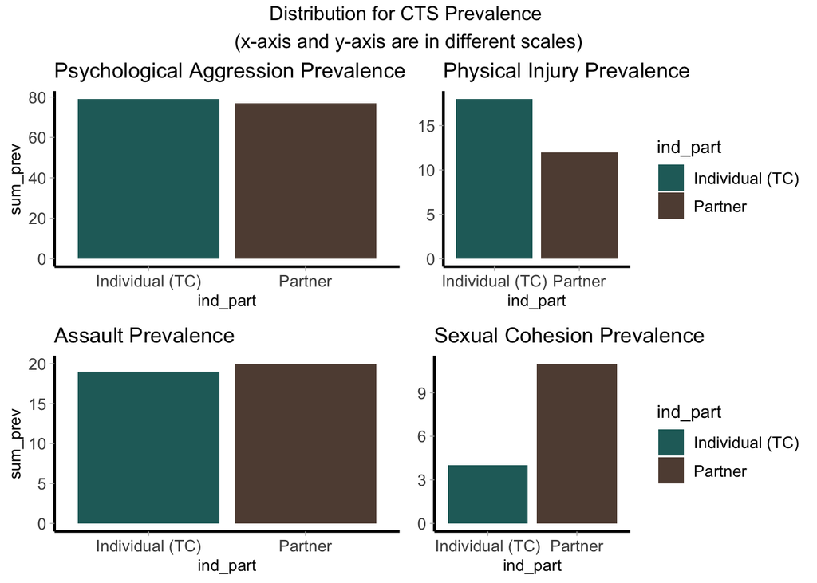

##### Mutuality distributions

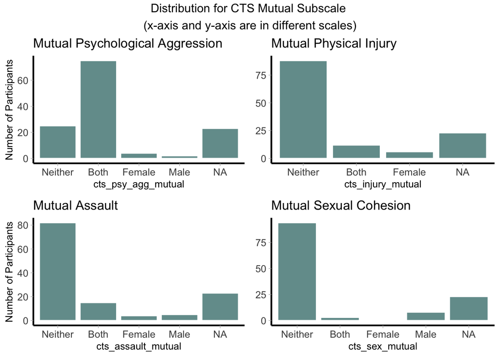

##### Negotiation distributions

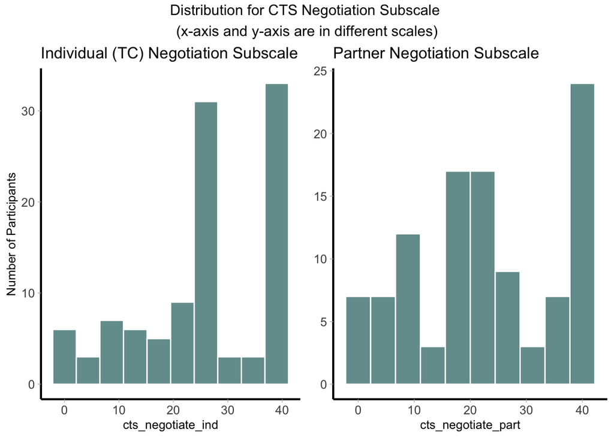

## Brief Child Abuse Potential Inventory (BCAP)

### BCAP Description

The BCAP is a self-report inventory used to assess parental child abuse risk.

For the present study, CONFIRM 34 items from the BCAP were collected and CONFIRM all 9 subscales were computed: Happiness, Feelings of Persecution, Loneliness, Family Conflict, Rigidity, Distress, Financial Insecurity, Lie, and Random Responding.

Four items (`q1`, `q2`, `q23`, and `q29`) should be reverse scored which is noted in the variable table below and the reverse scored variables are provided (`q1_r`, `q2_r`, `q23_r`, and `q29_r`). Higher scores on the BCAP indicates increased risk.

CONFIRM> The missing data rule was applied. Calculations were completed only with participants that had less than 20% missing data (this includes `-77` responses).

Reference: [@ondersma2005brief](https://www.tandfonline.com/doi/abs/10.1207/s15374424jccp3402_9?casa_token=ZIJ3j8CLmK0AAAAA:_ztEWiTg5FO0Y3Jb_fL-zTuyqSmH623f0Q91STiqNR3jYvQyPzUiTqLSW3E5_U4iAucWcpqvbHAUug); [DOI](https://doi.org/10.1207/s15374424jccp3402_9)

### BCAP Variables

#### Value Labels

All BCAP variables have the same response options.

| 0 | 1 |
| --- | --- |
| Disagree | Agree |

#### Survey Items

All BCAP survey items are presented in the following table:

| Variable | Description | Notes |
| --- | --- | --- |
| q1 | I am a happy person | This item should be reverse scored. `q1_r` is reverse scored |
| q2 | I know what is the right and wrong way to act | This item should be reverse scored. `q2_r` is reverse scored |
| q3 | People have caused me a lot of pain |  |
| q4 | I sometimes act without thinking |  |
| q5 | I am often lonely inside |  |
| q6 | My family fights a lot |  |
| q7 | Everything in a home should always be in its place |  |
| q8 | I often feel very upset |  |
| q9 | Sometimes I have bad thoughts |  |
| q10 | I sometimes worry that I will not have enough to eat |  |
| q11 | I am easily upset by my problems |  |
| q12 | Sometimes I feel all alone in the world |  |
| q13 | My family has problems getting along |  |
| q14 | Children should never disobey |  |
| q15 | I sometimes lose my temper |  |
| q16 | I often feel worthless |  |
| q17 | My family has many problems |  |
| q18 | It is okay to let a child stay in dirty diapers for a while |  |
| q19 | I am often upset and do not know why |  |
| q20 | Children should be quiet and listen |  |
| q21 | I sometimes fail to keep all of my promises |  |
| q22 | I often feel very alone |  |
| q23 | My life is good | This item should be reverse scored. `q23_r` is reverse scored |
| q24 | I am often upset |  |
| q25 | Other people have made my life unhappy |  |
| q26 | I sometimes say bad words |  |
| q27 | I am often depressed |  |
| q28 | Children should not learn how to swim |  |
| q29 | My life is happy | This item should be reverse scored. `q29_r` is reverse scored |
| q30 | I sometimes worry that my needs will not be met |  |
| q31 | I often feel alone |  |
| q32 | A child needs very strict rules |  |
| q33 | Other people have made my life hard |  |
| q34 | People sometimes take advantage of me |  |

#### Scale and Subscales

[output not shown]

*Range of possible values; `_r` Reverse scored variable

### Summary Statistics

#### Descriptive Statistics

For binary items:

| Variable | Disagree N | Disagree % | Agree N | Agree % | % Missing |  |
| --- | --- | --- | --- | --- | --- | --- |
| q1_r | 100 | 77.5% | 27 | 20.9% |  | 1.55% |
| q2_r | 126 | 97.7% | 1 | 0.8% | 1.55% |  |
| q3 | 21 | 16.3% | 106 | 82.2% | 1.55% |  |
| q4 | 36 | 27.9% | 92 | 71.3% | 0.78% |  |
| q5 | 67 | 51.9% | 61 | 47.3% | 0.78% |  |
| q6 | 84 | 65.1% | 40 | 31% | 3.88% |  |
| q7 | 55 | 42.6% | 72 | 55.8% | 1.55% |  |
| q8 | 98 | 76% | 30 | 23.3% | 0.78% |  |
| q9 | 66 | 51.2% | 62 | 48.1% | 0.78% |  |
| q10 | 107 | 82.9% | 21 | 16.3% | 0.78% |  |
| q11 | 75 | 58.1% | 53 | 41.1% | 0.78% |  |
| q12 | 63 | 48.8% | 64 | 49.6% | 1.55% |  |
| q13 | 61 | 47.3% | 62 | 48.1% | 4.65% |  |
| q14 | 110 | 85.3% | 15 | 11.6% | 3.1% |  |
| q15 | 40 | 31% | 87 | 67.4% | 1.55% |  |
| q16 | 83 | 64.3% | 44 | 34.1% | 1.55% |  |
| q17 | 57 | 44.2% | 69 | 53.5% | 2.33% |  |
| q18 | 128 | 99.2% | 0 | 0% | 0.78% |  |
| q19 | 94 | 72.9% | 34 | 26.4% | 0.78% |  |
| q20 | 106 | 82.2% | 18 | 14% | 3.88% |  |
| q21 | 59 | 45.7% | 67 | 51.9% | 2.33% |  |
| q22 | 71 | 55% | 57 | 44.2% | 0.78% |  |
| q23_r | 104 | 80.6% | 22 | 17.1% | 2.33% |  |
| q24 | 94 | 72.9% | 33 | 25.6% | 1.55% |  |
| q25 | 80 | 62% | 45 | 34.9% | 3.1% |  |
| q26 | 5 | 3.9% | 123 | 95.3% | 0.78% |  |
| q27 | 78 | 60.5% | 49 | 38% | 1.55% |  |
| q28 | 128 | 99.2% | 0 | 0% | 0.78% |  |
| q29_r | 98 | 76% | 29 | 22.5% | 1.55% |  |
| q30 | 62 | 48.1% | 65 | 50.4% | 1.55% |  |
| q31 | 71 | 55% | 57 | 44.2% | 0.78% |  |
| q32 | 72 | 55.8% | 52 | 40.3% | 3.88% |  |
| q33 | 68 | 52.7% | 59 | 45.7% | 1.55% |  |
| q34 | 40 | 31% | 87 | 67.4% | 1.55% |  |

For continuous total and subscale scores:

| Variable | Mean | SD | Range* | % Missing |
| --- | --- | --- | --- | --- |
| bcap_risk | 8.99 | 6.19 | 0-23 | 0.78% |
| bcap_happy | 0.61 | 1.01 | 0-3 | 0.78% |
| bcap_feel_pers | 1.64 | 1.08 | 0-3 | 0.78% |
| bcap_lonely | 1.87 | 1.82 | 0-4 | 0.78% |
| bcap_fam_conf | 1.34 | 1.19 | 0-3 | 0.78% |
| bcap_rigid | 1.23 | 1.05 | 0-4 | 0.78% |
| bcap_distress | 1.64 | 1.81 | 0-5 | 0.78% |
| bcap_poverty | 0.67 | 0.68 | 0-2 | 0.78% |
| bcap_lie | 4.05 | 1.6 | 0-6 | 0.78% |
| bcap_random | 0.01 | 0.09 | 0-1 | 0.78% |

*Range of data values

#### Distributions

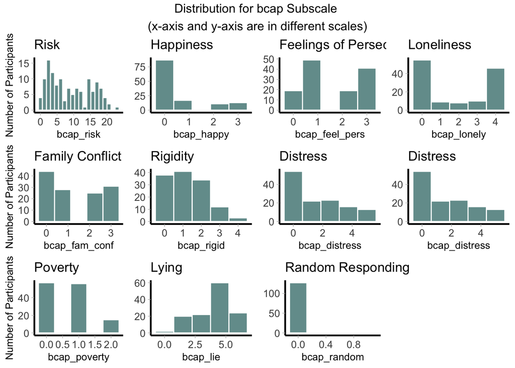

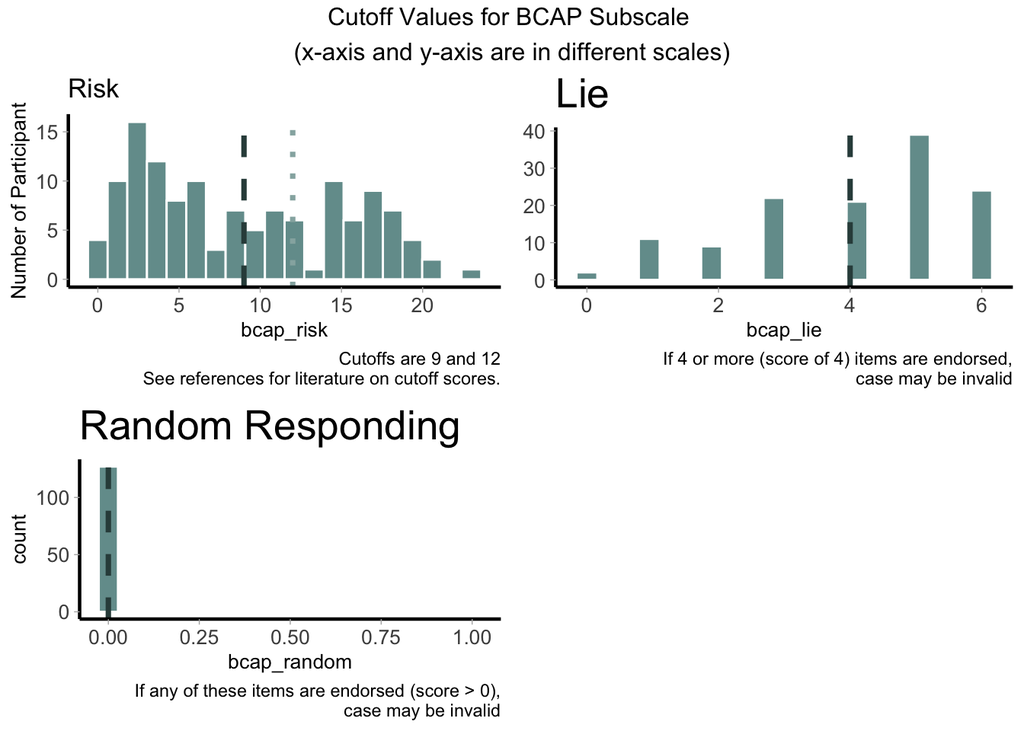

## Dyadic Adjustment Scale (DYADC)

### DYADC Description

The DYADC is a self-report measure used to assess dyadic adjustment (e.g., interpersonal tensions, dyadic satisfaction, dyadic functioning).

For the present study, all 32 items from the DYADC were collected, and the total score and all subscales are included: Consensus, Affective Expression, Satisfaction, and Cohesion.

Two items `e18` and `e19` should be reverse scored which is noted in the variable table below and the reverse scored variables are provided (`e18_r` and `e19_r`). Higher scores indicate more positive dyadic adjustment.

CONFIRM The missing data rule was Applied. Calculations were completed only with participants that had less than 20% missing data (this includes `-77` responses)

### DYADC Variables

#### Value Labels

The DYADC has multiple response options, value labels for each variable can be found in the survey items table below.

#### Survey Items

All DYADC survey items are presented in the following table:

Questions in this survey were not asked for TC who were incarcerated while the sruvey was been administered.

| Variable | Description | value | Notes |
| --- | --- | --- | --- |
| Thinking about the past 6 months, how often do you. . . |  |  |  |
| e1 | Handling family finances | 0 = Always Disagree 1 = Almost Always Disagree 2 = Frequently Disagree 3 = Occasionally Disagree 4 = Almost Always Agree 5 = Always Agree |  |
| e2 | Matters of recreation (what you do for fun in your free time) | 0 = Always Disagree 1 = Almost Always Disagree 2 = Frequently Disagree 3 = Occasionally Disagree 4 = Almost Always Agree 5 = Always Agree |  |
| e3 | Religious matters | 0 = Always Disagree 1 = Almost Always Disagree 2 = Frequently Disagree 3 = Occasionally Disagree 4 = Almost Always Agree 5 = Always Agree |  |
| e4 | Demonstration of Affection | 0 = Always Disagree 1 = Almost Always Disagree 2 = Frequently Disagree 3 = Occasionally Disagree 4 = Almost Always Agree 5 = Always Agree |  |
| e5 | Friends | 0 = Always Disagree 1 = Almost Always Disagree 2 = Frequently Disagree 3 = Occasionally Disagree 4 = Almost Always Agree 5 = Always Agree |  |
| e6 | Sex relations | 0 = Always Disagree 1 = Almost Always Disagree 2 = Frequently Disagree 3 = Occasionally Disagree 4 = Almost Always Agree 5 = Always Agree |  |
| e7 | Conventionality (correct or proper behavior) | 0 = Always Disagree 1 = Almost Always Disagree 2 = Frequently Disagree 3 = Occasionally Disagree 4 = Almost Always Agree 5 = Always Agree |  |
| e8 | Philosophy of life (the way you live your life) | 0 = Always Disagree 1 = Almost Always Disagree 2 = Frequently Disagree 3 = Occasionally Disagree 4 = Almost Always Agree 5 = Always Agree |  |
| e9 | Ways of dealing with parents or in-laws | 0 = Always Disagree 1 = Almost Always Disagree 2 = Frequently Disagree 3 = Occasionally Disagree 4 = Almost Always Agree 5 = Always Agree |  |
| e10 | Aims, goals, and things believed important | 0 = Always Disagree 1 = Almost Always Disagree 2 = Frequently Disagree 3 = Occasionally Disagree 4 = Almost Always Agree 5 = Always Agree |  |
| e11 | Amount of time spent together | 0 = Always Disagree 1 = Almost Always Disagree 2 = Frequently Disagree 3 = Occasionally Disagree 4 = Almost Always Agree 5 = Always Agree |  |
| e12 | Making major decisions | 0 = Always Disagree 1 = Almost Always Disagree 2 = Frequently Disagree 3 = Occasionally Disagree 4 = Almost Always Agree 5 = Always Agree |  |
| e13 | Household tasks | 0 = Always Disagree 1 = Almost Always Disagree 2 = Frequently Disagree 3 = Occasionally Disagree 4 = Almost Always Agree 5 = Always Agree |  |
| e14 | Leisure time and activities | 0 = Always Disagree 1 = Almost Always Disagree 2 = Frequently Disagree 3 = Occasionally Disagree 4 = Almost Always Agree 5 = Always Agree |  |
| e15 | Career decisions | 0 = Always Disagree 1 = Almost Always Disagree 2 = Frequently Disagree 3 = Occasionally Disagree 4 = Almost Always Agree 5 = Always Agree |  |
| e16 | Thinking about the past 6 months, how often do you discuss or have you considered divorce, separation, or terminating your relationship? | 0 = All the time 1 = Most of the time 2 = More often than not 3 = Occasionally 4 = Rarely 5 = Never |  |
| e17 | How often do you or your partner leave the house after a fight? | 0 = All the time 1 = Most of the time 2 = More often than not 3 = Occasionally 4 = Rarely 5 = Never |  |
| e18 | In general, how often do you think that things between you and your partner are going well? | 0 = Never 1 = Rarely 2 = Occasionally 3 = More often than not 4 = Most of the time 5 = All the time | This item should be reverse scored. `e18_r` is reverse scored |
| e19 | Thinking about the past 6 months, how often do you confide in your partner? | 0 = Never 1 = Rarely 2 = Occasionally 3 = More often than not 4 = Most of the time 5 = All the time | This item should be reverse scored. `e19_r` is reverse scored |
| e20 | How often do you ever regret that you are dating/married/living together? | 0 = All the time 1 = Most of the time 2 = More often than not 3 = Occasionally 4 = Rarely 5 = Never |  |
| e21 | How often do you and your partner quarrel? | 0 = All the time 1 = Most of the time 2 = More often than not 3 = Occasionally 4 = Rarely 5 = Never |  |
| e22 | Thinking about the past 6 months, how often do you and your partner “get on each other’s nerves”? | 0 = All the time 1 = Most of the time 2 = More often than not 3 = Occasionally 4 = Rarely 5 = Never |  |
| In the past 6 months, how often. . . |  |  |  |
| e23 | In the past 6 months, how often do you kiss your partner? | 0 = Never 1 = Rarely 2 = Occasionally 3 = Almost every day 4 = Every day |  |
| e24 | How often do you and your partner engage in outside interests together? | 0 = Never 1 = Rarely 2 = Occasionally 3 = Almost every day 4 = Every day |  |
| Thinking about the past 6 months,how often do you… |  |  |  |
| e25 | Thinking about the past 6 months, how often do you have an interesting chat? | 0 = Never 1 = Less than once a month 2 = Once or twice a month 3 = Once or twice a week 4 = Once a day 5 = More often |  |
| e26 | How often do you laugh together? | 0 = Never 1 = Less than once a month 2 = Once or twice a month 3 = Once or twice a week 4 = Once a day 5 = More often |  |
| e27 | How often do you calmly discuss something? | 0 = Never 1 = Less than once a month 2 = Once or twice a month 3 = Once or twice a week 4 = Once a day 5 = More often |  |
| e28 | Thinking about the past 6 months, how often do you work together on a project? | 0 = Never 1 = Less than once a month 2 = Once or twice a month 3 = Once or twice a week 4 = Once a day 5 = More often |  |
| Please indicate if items below were problems in your relationships in the past few weeks. |  |  |  |
| e29 | Being too tired for sex. | 0 = Yes 1 = No |  |
| e30 | Not showing love. | 0 = Yes 1 = No |  |
| e31 | Please indicate the number that best describes the degree of happiness in your relationship. | 0 = Extremely Unhappy 1 = Fairly Unhappy 2 = A Little Unhappy 3 = Happy 4 = Very Happy 5 = Extremely Happy 6 = Perfect |  |
| e32 | Which of the following statements best describes how you feel about the future of your relationship? Please indicate only one answer | 0 = My relationship can never succeed, and there is no more that I can do to keep the relationship going. 1 = It would be nice if it succeeded, but I refuse to do any more than I am doing now to keep … |  |

#### Scale and Subscales

| Variable Name | Scale (# of items) | Scale Construction | Range* | Alpha |
| --- | --- | --- | --- | --- |
| dyadc_total | DYADC Total score (32) | `e1`, `e2`, `e3`, `e4`, `e5`, `e6`, `e7`, `e8`, `e9`, `e10`, `e11`, `e12`, `e13`, `e14`, `e15`, `e16`, `e17`, `e18_r`, `e19_r`, `e20`, `e21`, `e22`, `e23`, `e24`, `e25`, `e26`, `e27`, `e28`, `e29`, `e… | 0-151 | 0.948 |
| dyadc_con | Consensus (13) | `e1`, `e2`, `e3`, `e4`, `e5`, `e6`, `e7`, `e8`, `e9`, `e10`, `e11`, `e12`, `e13` |  | 0.894 |
| dyadc_aff_exp | Affective Expression (4) | `e4`, `e6`, `e29`, `e30` |  | 0.638 |
| dyadc_satis | Satisfaction (10) | `e16`, `e17`, `e18_r`, `e19_r`, `e20`, `e21`, `e22`, `e23`, `e31`, `e32` |  | 0.919 |
| dyadc_cohes | Cohesion (5) | `e24`, `e25`, `e26`, `e27`, `e28` |  | 0.809 |

*Range of possible values; `_r` Reverse scored variable

### Summary Statistics

#### Descriptive Statistics

Descriptive statistics are presented below for each item, total, and subscale score.

For continuous items:

| Variable | Mean | SD | Range* | % Missing |
| --- | --- | --- | --- | --- |
| e1 | 3.54 | 1.19 | 0-5 | 25.58% |
| e2 | 3.47 | 1.11 | 0-5 | 23.26% |
| e3 | 4.10 | 1.34 | 0-5 | 27.13% |
| e4 | 3.83 | 1.12 | 0-5 | 23.26% |
| e5 | 3.59 | 1.26 | 0-5 | 23.26% |
| e6 | 4.13 | 1.14 | 0-5 | 23.26% |
| e7 | 3.61 | 1.25 | 0-5 | 24.03% |
| e8 | 3.64 | 1.09 | 0-5 | 23.26% |
| e9 | 3.41 | 1.41 | 0-5 | 24.81% |
| e10 | 3.78 | 1.1 | 0-5 | 23.26% |
| e11 | 3.63 | 1.12 | 0-5 | 23.26% |
| e12 | 3.76 | 1.13 | 0-5 | 24.81% |
| e13 | 3.46 | 1.4 | 0-5 | 24.81% |
| e14 | 3.54 | 1.1 | 0-5 | 23.26% |
| e15 | 3.83 | 1.13 | 0-5 | 24.03% |
| e16 | 3.91 | 1.32 | 0-5 | 24.03% |
| e17 | 3.76 | 1.51 | 0-5 | 23.26% |
| e18 | 3.46 | 1.3 | 0-5 | 23.26% |
| e19 | 3.97 | 1.23 | 0-5 | 23.26% |
| e20 | 4.06 | 1.38 | 0-5 | 23.26% |
| e21 | 3.38 | 1.12 | 0-5 | 23.26% |
| e22 | 3.09 | 1.03 | 0-5 | 23.26% |
| e23 | 3.35 | 1.04 | 0-4 | 23.26% |
| e24 | 2.14 | 0.93 | 0-4 | 23.26% |
| e25 | 3.62 | 1.21 | 0-5 | 23.26% |
| e26 | 4.22 | 1.08 | 0-5 | 23.26% |
| e27 | 3.84 | 1.21 | 0-5 | 23.26% |
| e28 | 2.72 | 1.43 | 0-5 | 23.26% |
| e31 | 3.66 | 1.44 | 0-6 | 23.26% |
| e32 | 3.64 | 1.29 | 0-5 | 24.81% |
| dyadc_total | 111.40 | 22.36 | 33-146 | 23.26% |
| dyadc_con | 47.38 | 10.96 | 11-65 | 23.26% |
| dyadc_aff_exp | 9.38 | 2.39 | 2-12 | 23.26% |
| dyadc_satis | 36.17 | 9.8 | 3-49 | 23.26% |
| dyadc_cohes | 16.54 | 4.45 | 1-23 | 23.26% |

*Range of data values

For binary items:

| Variable | No N | No % | Yes N | Yes % | % Missing |  |
| --- | --- | --- | --- | --- | --- | --- |
| e29 | 29 | 22.5% | 68 | 52.7% |  | 24.81% |
| e30 | 26 | 20.2% | 73 | 56.6% | 23.26% |  |

#### Distributions

Distributions are presented below for the total score and each subscale:

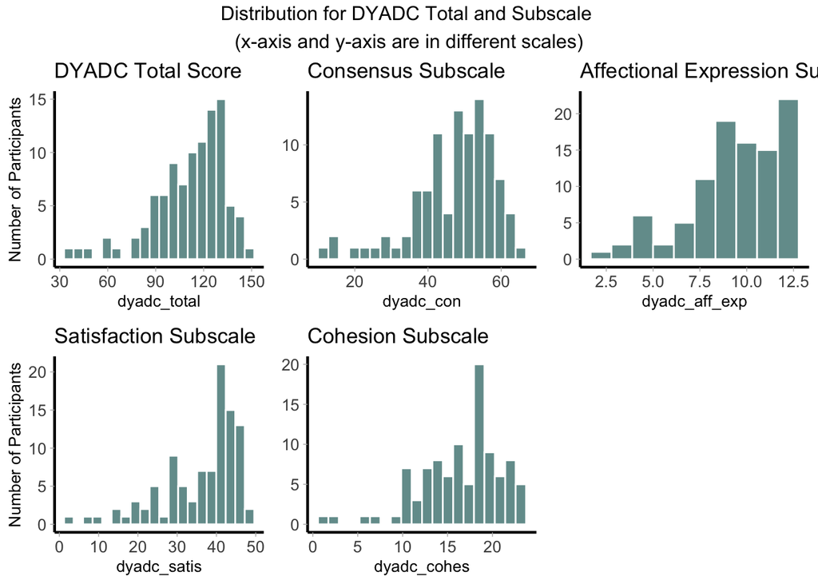

#### Clinical Categories

The distribution for the total score alongside clinical cutoffs are presented below.

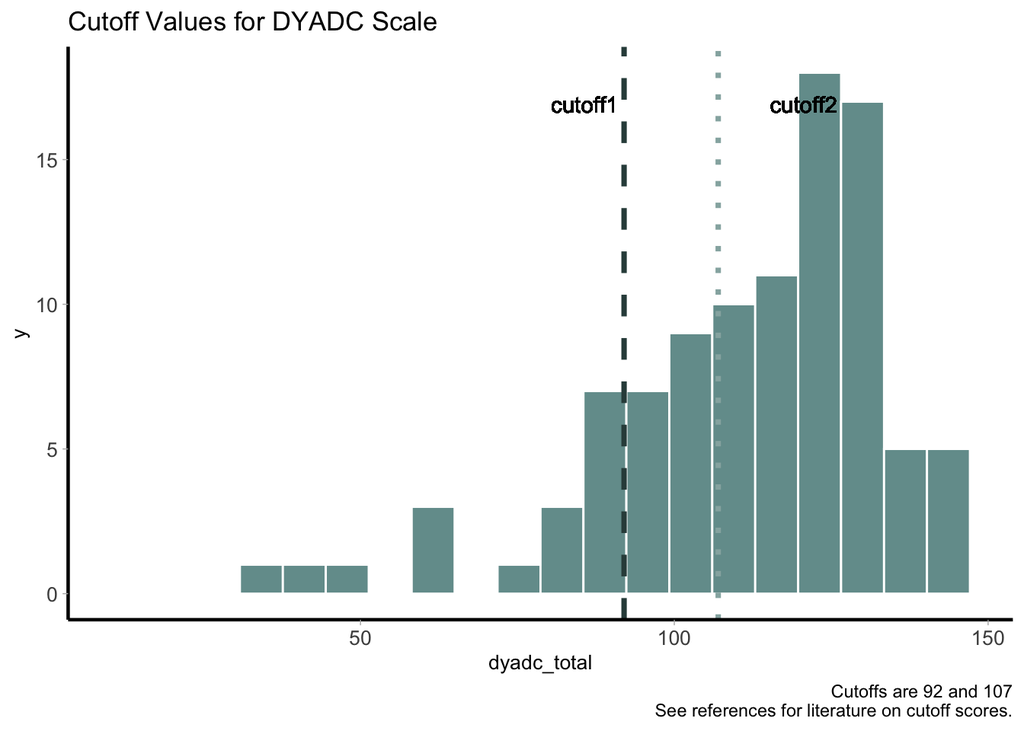